# Data Preparation, Heatmaps, and Differential Gene Expression Analysis

2023-05-29

# Introduction

In this tutorial, we are going to learn how to prepare data, create heatmaps, and perform differential gene expression analysis in R.

## Libraries

First, we will load the necessary libraries.

```r
library(readr)
library(reshape2)
library(pheatmap)
library(RColorBrewer)
library(viridis)
library(DESeq2)
```

## Data Preparation

We define a function `PrepareData` to prepare the data. This function takes in a filename and a path to a gene symbol mapping file, reads the file into a dataset, renames the first column to “Genes”, loads the gene symbol mapping information, and then replaces gene IDs in the dataset with corresponding gene symbols.

```r
PrepareData <- function(filename, libpath) {
  dataset <- read_csv(filename)
  names(dataset)[1] <- "Genes"
  entrez.cja <- readRDS(libpath)
  idx <- match(dataset$Genes, entrez.cja$gene_id)
  dataset$Genes <- entrez.cja$symbol[idx]
  return(dataset)
}
```

We then specify the path for the gene symbol mapping information and prepare the normalized and non-normalized datasets.

```r
libpath <- "data/entrez.rds"
dataset.norm <- PrepareData("data/cjaponica_data_normalized.csv", libpath)
dataset.nonorm <- PrepareData("data/cjaponica_data.csv", libpath)
```

## Creating Heatmaps

We set the seed for reproducibility and then create two heatmaps: one without row and column clustering, and another with row and column clustering.

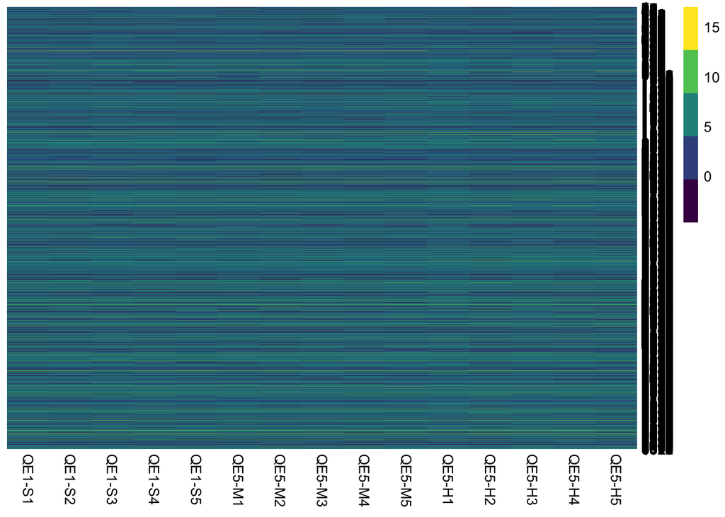

```r
set.seed(123)
pheatmap(dataset.norm[,-1], color = viridis(5), cluster_rows = FALSE, cluster_cols = FALSE, fontsize_number = 1, border_color=NA)
```

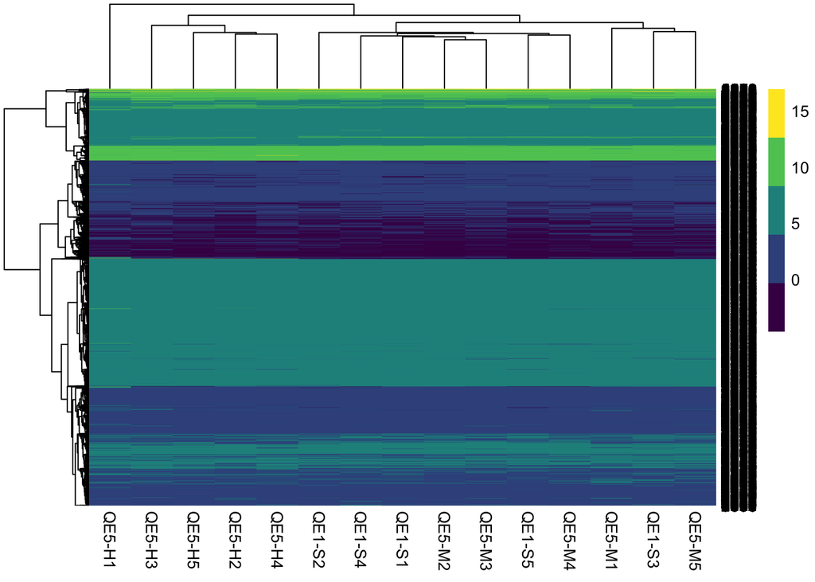

```r
pheatmap(dataset.norm[,-1], color = viridis(5), cluster_rows = TRUE, cluster_cols = TRUE, fontsize_number = 1, border_color=NA)
```

## Differential Gene Expression Analysis

We define sample conditions, create a DESeq dataset object, run DESeq2 analysis, get the 30 genes with smallest p-values, and remove genes with missing symbols.

```r
colData <- DataFrame(condition = factor(rep(c("Control", "Medium", "High"), each = 5)))
dds <- DESeqDataSetFromMatrix(countData = round(dataset.nonorm[,-1],0), colData = colData, design = ~ condition)
dds <- DESeq(dds)
res <- results(dds)
top_genes <- head(order(res$pvalue), 30)
gene.names <- dataset.norm[top_genes,1]
top_genes <- top_genes[!is.na(unlist(gene.names))]
```

Finally, we extract the differentially expressed genes (DEGs) from the normalized dataset and create a heatmap with row and column clustering for these DEGs.

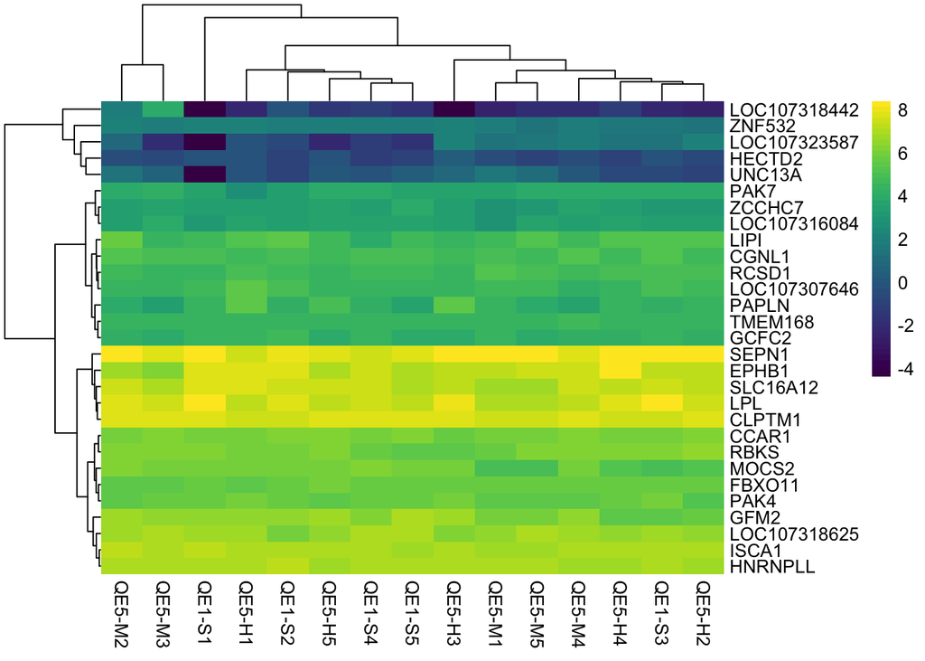

```r
dataset.norm.deg <- dataset.norm[top_genes,]
dataset.norm.deg <- as.data.frame(dataset.norm.deg)
rownames(dataset.norm.deg) <- unlist(dataset.norm.deg[,1])
pheatmap(dataset.norm.deg[,-1], color = viridis(50), cluster_rows = TRUE, cluster_cols = TRUE, fontsize_number = 1,
         border_color=NA, labels_row = dataset.norm.deg[,1])
```